# Chapter 4: Clustering and classification

*Clustering the Boston Suburbs*

We will be attempting to clusted the suburbs of Boston into groups based on housing values in them. The data is part of the MASS package in R, and a more complete description of it can be found [here](https://stat.ethz.ch/R-manual/R-devel/library/MASS/html/Boston.html)

It includes the following variables:

```r
# clear all variables possibly left over from previous sessions
rm(list = ls())

# load libraries

library(GGally)
library(ggplot2)
library(MASS)# access the MASS package
library(dplyr)
# load the data
data("Boston")

# explore the dataset
str(Boston)
```

```
## 'data.frame':    506 obs. of  14 variables:
##  $ crim   : num  0.00632 0.02731 0.02729 0.03237 0.06905 ...
##  $ zn     : num  18 0 0 0 0 0 12.5 12.5 12.5 12.5 ...
##  $ indus  : num  2.31 7.07 7.07 2.18 2.18 2.18 7.87 7.87 7.87 7.87 ...
##  $ chas   : int  0 0 0 0 0 0 0 0 0 0 ...
##  $ nox    : num  0.538 0.469 0.469 0.458 0.458 0.458 0.524 0.524 0.524 0.524 ...
##  $ rm     : num  6.58 6.42 7.18 7 7.15 ...
##  $ age    : num  65.2 78.9 61.1 45.8 54.2 58.7 66.6 96.1 100 85.9 ...
##  $ dis    : num  4.09 4.97 4.97 6.06 6.06 ...
##  $ rad    : int  1 2 2 3 3 3 5 5 5 5 ...
##  $ tax    : num  296 242 242 222 222 222 311 311 311 311 ...
##  $ ptratio: num  15.3 17.8 17.8 18.7 18.7 18.7 15.2 15.2 15.2 15.2 ...
##  $ black  : num  397 397 393 395 397 ...
##  $ lstat  : num  4.98 9.14 4.03 2.94 5.33 ...
##  $ medv   : num  24 21.6 34.7 33.4 36.2 28.7 22.9 27.1 16.5 18.9 ...
```

```r
dim(Boston)
```

```
## [1] 506  14
```

Let’s explore the distributions and relations of the variables:

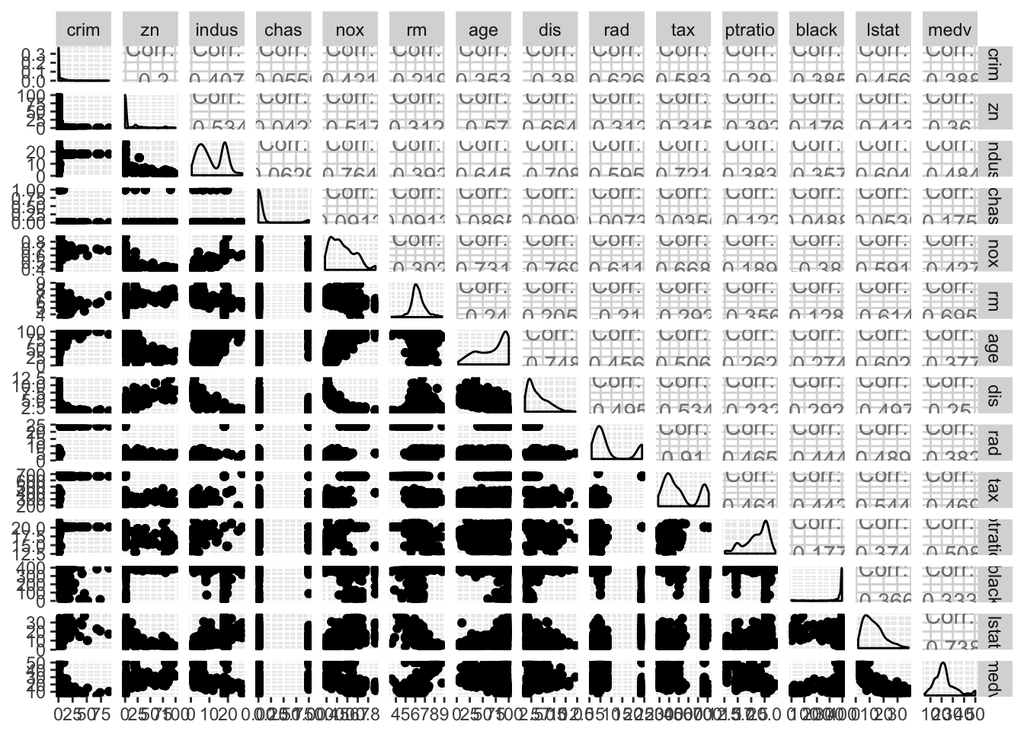

```r
# plot matrix of the variables
p <- ggpairs(Boston, mapping = aes(), lower = list(combo = wrap("facethist", bins = 20)))
p
```

Most of the variables do not seem very normally distributed. In fact, only the variable rm (average number of rooms per dwelling) is anywhere near normal, and even that is slightly skewed. Most of the others have a very wide (NO$_X$, nitrogen oxides in the air), or multimodal (more than one peak: indus, the proportion of non-retail business acres per town) distribution. This could be a problem later on: one of the assumptions of linear discriminant analysis (LDA) that we will be using to classify the suburbs is that the variables used for the classification are normally distributed (within groups). Now we are of course only looking at the total distributions: it would be possible that when looking at the distributions within the groups, the variables would be normally distributed. However, I find this highly unlikely.

The relationships between the variables also seem to vary. Some seem pretty linear, such as the relationship between rm and medv (median value of owner-occupied homes in $1000s.). Some others seem totally non-linear, like NO$_X$ and dis (weighted mean of distances to five Boston employment centres.): here the relationship is a negative one, which makes sense: the farther you are from the centre, the less air pollution you have. Still others are just weird, like age (proportion of owner-occupied units built prior to 1940.) and black (1000(Bk - 0.63)$^2$ where Bk is the proportion of blacks by town.).

Finally, let’s look at some summary statistics of the variables:

```r
library(pastecs) # load pastecs library for easy calculation and presenting of standard deviations
round(stat.desc(Boston),3)[c(1,4,5,8,9,13),] #printing N, min, max, med, mean, sd
```

```
##            crim      zn   indus    chas     nox      rm     age     dis
## nbr.val 506.000 506.000 506.000 506.000 506.000 506.000 506.000 506.000
## min       0.006   0.000   0.460   0.000   0.385   3.561   2.900   1.130
## max      88.976 100.000  27.740   1.000   0.871   8.780 100.000  12.127
## median    0.257   0.000   9.690   0.000   0.538   6.208  77.500   3.207
## mean      3.614  11.364  11.137   0.069   0.555   6.285  68.575   3.795
## std.dev   8.602  23.322   6.860   0.254   0.116   0.703  28.149   2.106
##             rad     tax ptratio   black   lstat    medv
## nbr.val 506.000 506.000 506.000 506.000 506.000 506.000
## min       1.000 187.000  12.600   0.320   1.730   5.000
## max      24.000 711.000  22.000 396.900  37.970  50.000
## median    5.000 330.000  19.050 391.440  11.360  21.200
## mean      9.549 408.237  18.456 356.674  12.653  22.533
## std.dev   8.707 168.537   2.165  91.295   7.141   9.197
```

We can see that both the means and the standard deviations of the variables vary wildly. The standard deviations should be the same for each variable if we want to use them for classification. Only in this way can we assess the similarity of observations using the distances between them. So let’s standardize the variables.

```r
# center and standardize variables
boston_scaled <- as.data.frame(scale(Boston))

round(stat.desc(boston_scaled),3)[c(1,4,5,8,9,13),] #printing N, min, max, med, mean, sd
```

```
##            crim      zn   indus    chas     nox      rm     age     dis
## nbr.val 506.000 506.000 506.000 506.000 506.000 506.000 506.000 506.000
## min      -0.419  -0.487  -1.556  -0.272  -1.464  -3.876  -2.333  -1.266
## max       9.924   3.800   2.420   3.665   2.730   3.552   1.116   3.957
## median   -0.390  -0.487  -0.211  -0.272  -0.144  -0.108   0.317  -0.279
## mean      0.000   0.000   0.000   0.000   0.000   0.000   0.000   0.000
## std.dev   1.000   1.000   1.000   1.000   1.000   1.000   1.000   1.000
##             rad     tax ptratio   black   lstat    medv
## nbr.val 506.000 506.000 506.000 506.000 506.000 506.000
## min      -0.982  -1.313  -2.705  -3.903  -1.530  -1.906
## max       1.660   1.796   1.637   0.441   3.545   2.987
## median   -0.522  -0.464   0.275   0.381  -0.181  -0.145
## mean      0.000   0.000   0.000   0.000   0.000   0.000
## std.dev   1.000   1.000   1.000   1.000   1.000   1.000
```

Now the means are all zero, and the standard deviations one. The non-normality of the variables can be seen, as for some variables the median differs considerably from the mean of zero. Also the minima and maxima of some variables differ a lot. For the rm, which seemed the most normal variable, they are quite close together, and the median is not too far from the mean either.

Next we will classify the suburbs into classes based on the crime rate.

```r
# save the scaled crim as scaled_crim
scaled_crim <- boston_scaled$crim

# create a quantile vector of crim
bins <- quantile(scaled_crim)

# create a categorical variable 'crime'
crime <- cut(scaled_crim, breaks = bins, include.lowest = TRUE, label = c("low", "med_low", "med_high", "high"))

# remove original crim from the dataset
boston_scaled <- dplyr::select(boston_scaled, -crim)

# add the new categorical value to scaled data
boston_scaled <- data.frame(boston_scaled, crime)
```

Now that the classification is done, we will split the data set into a training set (train), which includes 80% of the observations. We’ll choose these “randomly”, but using the same seed for reproducibility.

```r
set.seed(777)

# number of rows in the Boston dataset
n <- nrow(boston_scaled)

# choose randomly 80% of the rows
ind <- sample(n,  size = n * 0.8)

# create train set
train <- boston_scaled[ind,]

# create test set
test <- boston_scaled[-ind,]
```

Having the training and test data done, we are ready to start classifying using LDA. We will try to classify the suburbs into crime rate classes, based on the other data. So, let’s do that next, and plot the results.

```r
# linear discriminant analysis
lda.fit <- lda(crime ~ ., data = train)

# print the lda.fit object
lda.fit
```

```
## Call:
## lda(crime ~ ., data = train)
##
## Prior probabilities of groups:
##       low   med_low  med_high      high
## 0.2623762 0.2425743 0.2450495 0.2500000
##
## Group means:
##                   zn      indus        chas        nox         rm
## low       0.92730082 -0.8767338 -0.08661679 -0.8547381  0.4242730
## med_low  -0.05146847 -0.3489056 -0.03128211 -0.5930089 -0.1193522
## med_high -0.39022525  0.2310140  0.16512651  0.4127645  0.0666368
## high     -0.48724019  1.0171306 -0.03844192  1.0596527 -0.4483671
##                 age        dis        rad        tax    ptratio
## low      -0.8227282  0.8170133 -0.6980048 -0.7555661 -0.4213212
## med_low  -0.3669777  0.4055281 -0.5412349 -0.4869781 -0.0968224
## med_high  0.4252589 -0.3480782 -0.4134380 -0.2909456 -0.2622028
## high      0.7843150 -0.8417034  1.6379981  1.5139626  0.7806252
##                black       lstat        medv
## low       0.37833274 -0.75939334  0.50387326
## med_low   0.35459501 -0.14229320  0.01562712
## med_high  0.06365885  0.02395697  0.14118649
## high     -0.77827648  0.90992464 -0.67672339
##
## Coefficients of linear discriminants:
##                  LD1          LD2         LD3
## zn       0.120963109  0.656131688 -1.07036451
## indus   -0.030280789 -0.299415376  0.10135145
## chas    -0.005662114 -0.027978089  0.05057478
## nox      0.445091047 -0.823125480 -1.20770111
## rm       0.032150810 -0.080017358 -0.15621484
## age      0.274098760 -0.314531013 -0.32791413
## dis     -0.052399339 -0.380304196  0.15239197
## rad      3.083594673  1.011531861 -0.28653303
## tax      0.094370508 -0.088274949  0.84023115
## ptratio  0.164276113 -0.008193075 -0.33669584
## black   -0.132563536  0.045269082  0.15738547
## lstat    0.188199230 -0.178041437  0.56378242
## medv     0.105435628 -0.429509165 -0.04316085
##
## Proportion of trace:
##    LD1    LD2    LD3
## 0.9518 0.0354 0.0128
```

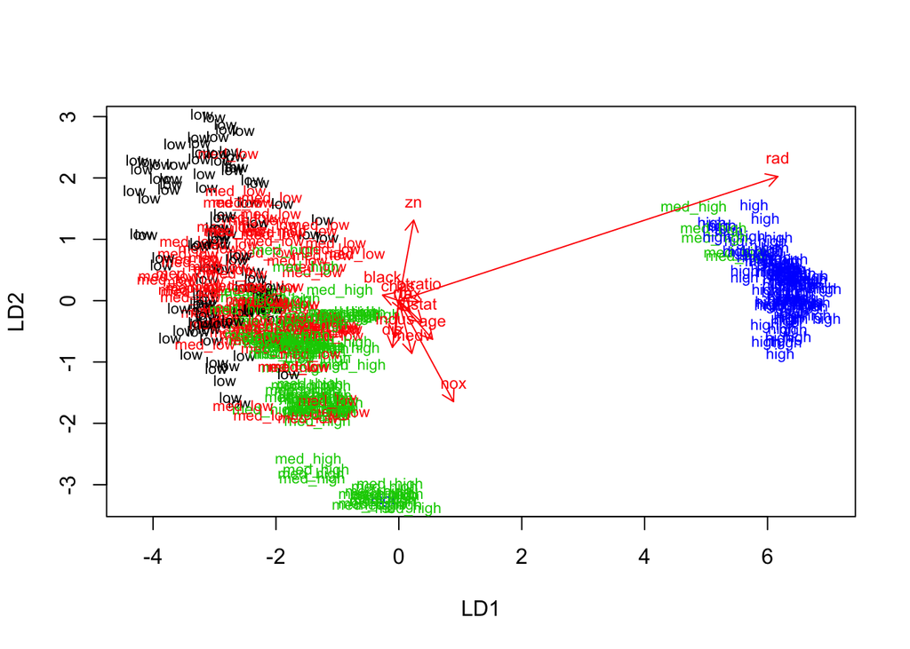

```r
# the function for lda biplot arrows
lda.arrows <- function(x, myscale = 1, arrow_heads = 0.1, color = "red", tex = 0.75, choices = c(1,2)){
  heads <- coef(x)
  arrows(x0 = 0, y0 = 0,
         x1 = myscale * heads[,choices[1]],
         y1 = myscale * heads[,choices[2]], col=color, length = arrow_heads)
  text(myscale * heads[,choices], labels = row.names(heads),
       cex = tex, col=color, pos=3)
}

# target classes as numeric
classes <- as.numeric(train$crime)

# plot the lda results
plot(lda.fit, dimen = 2, col = classes, pch = classes)
lda.arrows(lda.fit, myscale = 2)
```

According to the plot, the suburbs with the high crime rate get very well separated from the others (not regarding the few medium crime rate suburbs that cluster with the high ones). For the other classes the classification is a bit more ambiguous: they are not separated that well on the plot. Next, let’s see how well the model does classifying the test data. For that, we’ll remove the class variable from the test data, and save it separately. That way we can be absolutely sure that the model does not see the actual classes and cheat:)

```r
# save the correct classes from test data
correct_classes <- test$crime

# remove the crime variable from test data
test <- dplyr::select(test, -crime)
```

Now we are ready to classify the test data. Let’s do that, and see the how well the model did.

```r
# predict classes with test data
lda.pred <- predict(lda.fit, newdata = test)

# cross tabulate the results
table(correct = correct_classes, predicted = lda.pred$class)
```

```
##           predicted
## correct    low med_low med_high high
##   low       14       7        0    0
##   med_low    3      19        6    0
##   med_high   1       6       19    1
##   high       0       0        0   26
```

Based on the table, the result seems pretty good! All in all, 78 of the suburbs are correctly classified, while only 24 are not. Again the high crime rate class seems to perform the best: out of the 26 suburbs with high crime rate, 26 were correcrly classified. That is a whopping 100 percent! Also, only 1 observation that did not belong to the “high” group was misclassified in that group. So cool, our LDA worked pretty well.

Now that the LDA is done, let’s move on to k-means clustering. We will first clear all variables from the memory, and reload the Boston data set.

```r
# clear all variables possibly left over from previous sessions
rm(list = ls())

# load the data
data("Boston")

# explore the dataset
str(Boston)
```

```
## 'data.frame':    506 obs. of  14 variables:
##  $ crim   : num  0.00632 0.02731 0.02729 0.03237 0.06905 ...
##  $ zn     : num  18 0 0 0 0 0 12.5 12.5 12.5 12.5 ...
##  $ indus  : num  2.31 7.07 7.07 2.18 2.18 2.18 7.87 7.87 7.87 7.87 ...
##  $ chas   : int  0 0 0 0 0 0 0 0 0 0 ...
##  $ nox    : num  0.538 0.469 0.469 0.458 0.458 0.458 0.524 0.524 0.524 0.524 ...
##  $ rm     : num  6.58 6.42 7.18 7 7.15 ...
##  $ age    : num  65.2 78.9 61.1 45.8 54.2 58.7 66.6 96.1 100 85.9 ...
##  $ dis    : num  4.09 4.97 4.97 6.06 6.06 ...
##  $ rad    : int  1 2 2 3 3 3 5 5 5 5 ...
##  $ tax    : num  296 242 242 222 222 222 311 311 311 311 ...
##  $ ptratio: num  15.3 17.8 17.8 18.7 18.7 18.7 15.2 15.2 15.2 15.2 ...
##  $ black  : num  397 397 393 395 397 ...
##  $ lstat  : num  4.98 9.14 4.03 2.94 5.33 ...
##  $ medv   : num  24 21.6 34.7 33.4 36.2 28.7 22.9 27.1 16.5 18.9 ...
```

```r
dim(Boston)
```

```
## [1] 506  14
```

We already know what’s in the data, so let’s not spend more time looking at that. Instead, let’s again standardize the data to get sensible distance measures for estimating the similarity of observations. Then, let’s calculate the Euclidean distances.

```r
# center and standardize variables
boston_scaled <- as.data.frame(scale(Boston))

# euclidean distance matrix
dist_eu <- dist(boston_scaled)

# look at the summary of the distances
summary(dist_eu)
```

```
##    Min. 1st Qu.  Median    Mean 3rd Qu.    Max.
##  0.1343  3.4620  4.8240  4.9110  6.1860 14.4000
```

Seems that there is at least some variation in the distances: the closest values are only 0.13 units apart, while the farthest are 14 units apart. We’ll try and see if we can cluster the observations using k-means next. To begin with, we’ll request 4 clusters. So next we’ll run the analyses, and plot the results

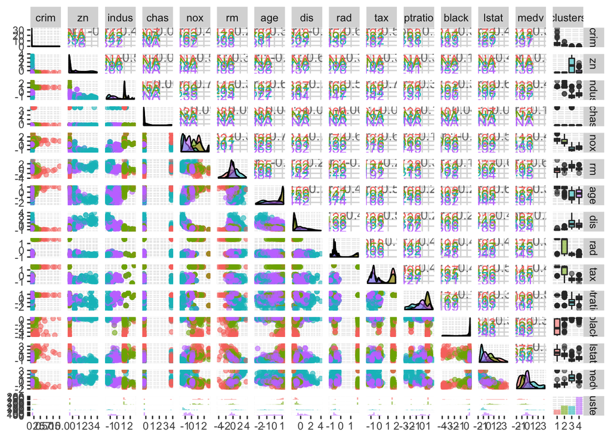

```r
# k-means clustering
km <-kmeans(dist_eu, centers = 4)
boston_scaled$clusters = as.factor(km$cluster)

# plot matrix of the variables
p2 <- ggpairs(boston_scaled, mapping = aes(col = clusters, alpha = 0.3), lower = list(combo = wrap("facethist", bins = 20)))
p2
```

Actually, it now seems that some of the non-normal variables might after all be more normal withing groups. For example the lstat (lower status of the population (percent)), which originally had a very wide and skewed distribution, now seeems to consist of slightly more normal, though still skewed, distributions.

Some of the variables seem to be better at separating the clusters than others. Still all of the variables seem to vary across clusters. For exapmle the aforementioned lstat, and NO$_X$ seem to separate the clusters nicely, as do the tax, medv and indus.